# 7027HW1

# Q1

This question uses the variables horsepower and mpg from the Auto data as part of the ISLR package. We will treat horsepower as the predictor and mpg as the response.

## (a) Use the poly() function to fit a cubic polynomial regression to predict mpg using horsepower. Report the regression output, and plot the resulting data and polynomial fits.

```r
fit1a<-lm(mpg~poly(horsepower,3),data=Auto)
summary(fit1a)
```

```
##
## Call:
## lm(formula = mpg ~ poly(horsepower, 3), data = Auto)
##
## Residuals:
##      Min       1Q   Median       3Q      Max
## -14.7039  -2.4491  -0.1519   2.2035  15.8159
##
## Coefficients:
##                      Estimate Std. Error t value Pr(>|t|)
## (Intercept)            23.446      0.221 106.105   <2e-16 ***
## poly(horsepower, 3)1 -120.138      4.375 -27.460   <2e-16 ***
## poly(horsepower, 3)2   44.090      4.375  10.078   <2e-16 ***
## poly(horsepower, 3)3   -3.949      4.375  -0.903    0.367
## ---
## Signif. codes:  0 '***' 0.001 '**' 0.01 '*' 0.05 '.' 0.1 ' ' 1
##
## Residual standard error: 4.375 on 388 degrees of freedom
## Multiple R-squared:  0.6882, Adjusted R-squared:  0.6858
## F-statistic: 285.5 on 3 and 388 DF,  p-value: < 2.2e-16
```

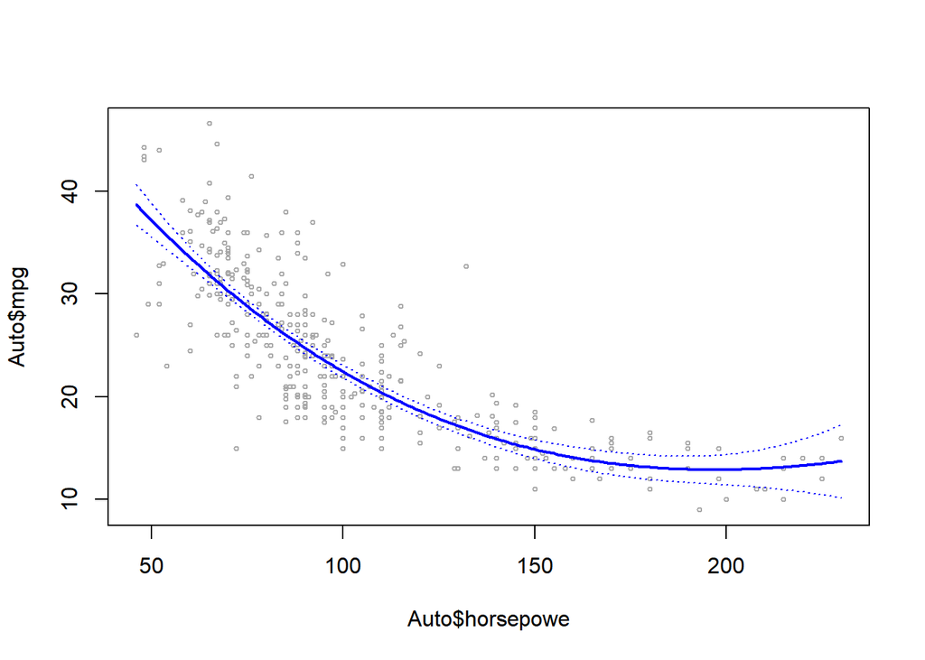

```r
horsepowerlims=range(Auto$horsepower)
horsepower.grid=seq(from=horsepowerlims[1],to=horsepowerlims[2])
preds<-predict(fit1a,newdata=list(horsepower=horsepower.grid),se=TRUE)
plot(Auto$horsepowe,Auto$mpg,xlim=horsepowerlims,cex=.5,col="darkgray")
lines(horsepower.grid,preds$fit,lwd=2,col="blue")
se.bands <-cbind(preds$fit+2*preds$se.fit,preds$fit-2*preds$se.fit)
matlines(horsepower.grid,se.bands,lwd=1, col='blue',lty=3)
```

## (b) Use the bs() function to fit a cubic spline to predict mpg using horsepower. Report the output for the fit using six degrees of freedom. How did you choose the knots? Plot the resulting fit.

```r
fit1b<-lm(mpg~bs(horsepower,df=6),data=Auto)
summary(fit1b)
```

```
##
## Call:
## lm(formula = mpg ~ bs(horsepower, df = 6), data = Auto)
##
## Residuals:
##      Min       1Q   Median       3Q      Max
## -15.5656  -2.5966  -0.2456   2.2574  15.2709
##
## Coefficients:
##                         Estimate Std. Error t value Pr(>|t|)
## (Intercept)               32.591      1.931  16.878  < 2e-16 ***
## bs(horsepower, df = 6)1    5.801      3.293   1.761    0.079 .
## bs(horsepower, df = 6)2   -2.609      1.972  -1.323    0.187
## bs(horsepower, df = 6)3  -11.374      2.241  -5.076 6.02e-07 ***
## bs(horsepower, df = 6)4  -16.977      2.622  -6.475 2.90e-10 ***
## bs(horsepower, df = 6)5  -23.202      3.557  -6.523 2.18e-10 ***
## bs(horsepower, df = 6)6  -18.161      2.829  -6.420 4.03e-10 ***
## ---
## Signif. codes:  0 '***' 0.001 '**' 0.01 '*' 0.05 '.' 0.1 ' ' 1
##
## Residual standard error: 4.294 on 385 degrees of freedom
## Multiple R-squared:  0.702,  Adjusted R-squared:  0.6974
## F-statistic: 151.2 on 6 and 385 DF,  p-value: < 2.2e-16
```

```r
attr(bs(Auto$horsepower,df=6),"knots")
```

```
## [1]  75.0  93.5 126.0
```

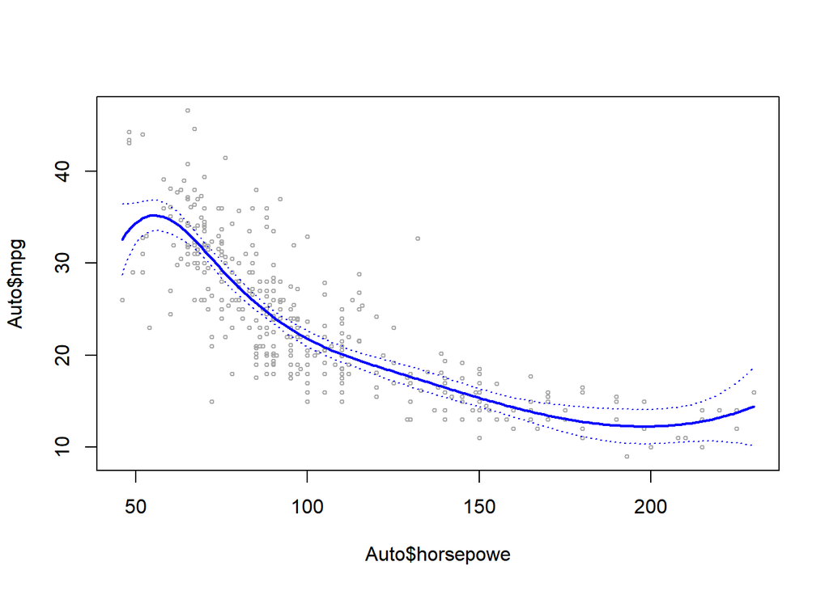

```r
horsepowerlims=range(Auto$horsepower)
horsepower.grid=seq(from=horsepowerlims[1],to=horsepowerlims[2])
preds<-predict(fit1b,newdata=list(horsepower=horsepower.grid),se=TRUE)
plot(Auto$horsepowe,Auto$mpg,xlim=horsepowerlims,cex=.5,col="darkgray")
lines(horsepower.grid,preds$fit,lwd=2,col="blue")
se.bands <-cbind(preds$fit+2*preds$se.fit,preds$fit-2*preds$se.fit)
matlines(horsepower.grid,se.bands,lwd=1, col='blue',lty=3)
```

## (c) Now fit a cubic spline for degrees of freedom ranging from 4 to 12, and plot the resulting fits as well as the resulting RSS. Describe the results obtained.

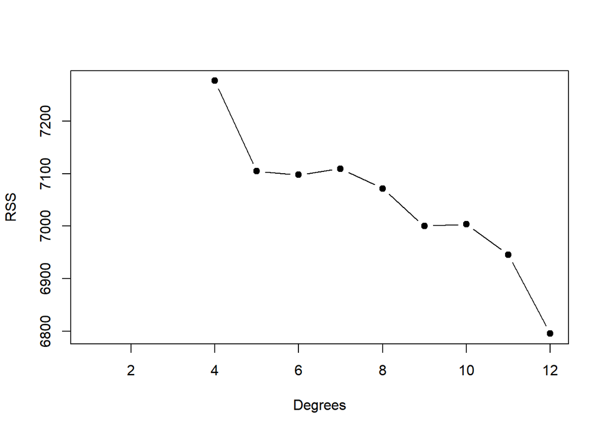

```r
rss.errors <- c()

for(i in 4:12){
  fit1c<-lm(mpg~bs(horsepower,i),data=Auto)
  rss.errors[i] <- sum(fit1c$residuals^2)
}
plot(rss.errors, type='b', pch = 19, xlab = 'Degrees', ylab='RSS')
```

```r
which.min(rss.errors)
```

```
## [1] 12
```

The smallest RSS occurs when df=12.

## (d) Perform cross-validation to select the best degrees of freedom for a cubic spline on this data. Describe your results.

```r
require(boot)
set.seed(1)

cv.errors <- rep(NaN, 12)

for (i in 4:12){
fit1d<-glm(mpg~bs(horsepower,i),data=Auto)
cv.errors[i] <- cv.glm(Auto, fit1d, K=10)$delta[1]
}
cv.errors
```

```
##  [1]      NaN      NaN      NaN 19.29917 18.97020 18.90182 19.11808 19.12108
##  [9] 19.12523 19.14848 18.89318 18.85129
```

```r
which.min(cv.errors)
```

```
## [1] 12
```

The optimal df selected by cross-validation is 12.

## (e) Use the ns() function to fit a natural cubic spline to predict mpg using horsepower. Report the output for the fit using degrees of freedom s.t. number of knots is the same as (b). Plot the resulting fit.

```r
fit1e<-lm(mpg~ns(horsepower,df=6),data=Auto)
summary(fit1e)
```

```
##
## Call:
## lm(formula = mpg ~ ns(horsepower, df = 6), data = Auto)
##
## Residuals:
##      Min       1Q   Median       3Q      Max
## -15.9491  -2.6183  -0.1595   2.3508  15.1349
##
## Coefficients:
##                         Estimate Std. Error t value Pr(>|t|)
## (Intercept)               34.738      1.509  23.021  < 2e-16 ***
## ns(horsepower, df = 6)1   -8.210      1.594  -5.149 4.18e-07 ***
## ns(horsepower, df = 6)2  -13.046      1.835  -7.108 5.76e-12 ***
## ns(horsepower, df = 6)3  -14.577      1.886  -7.730 9.50e-14 ***
## ns(horsepower, df = 6)4  -22.802      1.624 -14.039  < 2e-16 ***
## ns(horsepower, df = 6)5  -22.758      3.512  -6.480 2.81e-10 ***
## ns(horsepower, df = 6)6  -20.849      1.742 -11.967  < 2e-16 ***
## ---
## Signif. codes:  0 '***' 0.001 '**' 0.01 '*' 0.05 '.' 0.1 ' ' 1
##
## Residual standard error: 4.302 on 385 degrees of freedom
## Multiple R-squared:  0.7009, Adjusted R-squared:  0.6962
## F-statistic: 150.4 on 6 and 385 DF,  p-value: < 2.2e-16
```

```r
attr(ns(Auto$horsepower,df=6),"knots")
```

```
## [1]  70.0  84.0  93.5 110.0 150.0
```

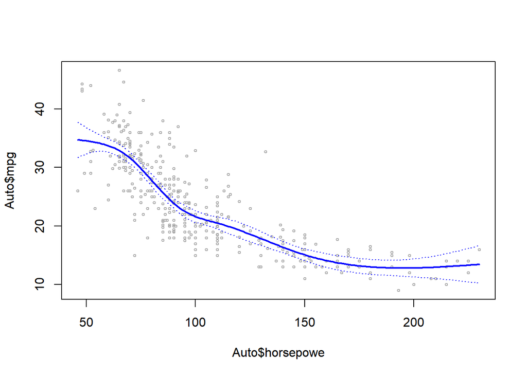

```r
horsepowerlims=range(Auto$horsepower)
horsepower.grid=seq(from=horsepowerlims[1],to=horsepowerlims[2])
preds<-predict(fit1e,newdata=list(horsepower=horsepower.grid),se=TRUE)
plot(Auto$horsepowe,Auto$mpg,xlim=horsepowerlims,cex=.5,col="darkgray")
lines(horsepower.grid,preds$fit,lwd=2,col="blue")
se.bands <-cbind(preds$fit+2*preds$se.fit,preds$fit-2*preds$se.fit)
matlines(horsepower.grid,se.bands,lwd=1, col='blue',lty=3)
```

## (f) Now fit a natural cubic spline for a range of degrees of freedom, and plot the resulting fits as well as the resulting RSS. Describe the results obtained.

```r
rss.errors <- rep(NA, 12)

for(i in 4:12){
  fit1f <- lm(mpg ~ bs(horsepower, df=i), data=Auto)
  rss.errors[i] <- sum(fit1f$residuals^2)
}
rss.errors
```

```
##  [1]       NA       NA       NA 7276.505 7104.849 7097.721 7109.314 7071.811
##  [9] 7000.026 7004.008 6945.820 6795.638
```

```r
which.min(rss.errors)
```

```
## [1] 12
```

The smallest RSS occurs when df=12.

## (g) Perform cross-validation to select the best degrees of freedom for a natural cubic spline on this data. Describe your results.

```r
require(boot)
set.seed(1)

cv.errors <- rep(NaN, 12)

for (i in 1:12){
  fit1g<-glm(mpg~ns(horsepower,i),data=Auto)
  cv.errors[i] <- cv.glm(Auto, fit1g, K=10)$delta[1]
}

cv.errors
```

```
##  [1] 24.21538 19.11813 19.11203 19.01015 19.11220 18.95109 18.72917 18.69287
##  [9] 18.90282 18.32691 18.86966 19.18424
```

```r
which.min(cv.errors)
```

```
## [1] 10
```

The optimal df selected by cross-validation is 10.

## (h) Compare your results of (d) and (g), choose the best model for cubic spline and natural cubic spline respectively. Which one performs the best? With how many knots?

The result of (g) is smaller than (d), thus we choose natural cubic spline. The df is 10. There are 9 knots in R.

# Q2

This problem involves the Boston data set which is from the MASS package. We will fit classification models in order to predict whether a given suburb has a crime rate above or below the median. Preliminary step: Create an extra column crimAbvMed which is 1 if crime rate is above median and 0 otherwise. Then delete the crime rate column crim.

```r
require(MASS)

data(Boston)
attach(Boston)
```

```r
Boston$crimAbvMed <- ifelse(Boston$crim > median(Boston$crim), 1, 0)
Boston <- subset(Boston, select = -c(crim))
head(Boston)
```

```
##   zn indus chas   nox    rm  age    dis rad tax ptratio  black lstat medv
## 1 18  2.31    0 0.538 6.575 65.2 4.0900   1 296    15.3 396.90  4.98 24.0
## 2  0  7.07    0 0.469 6.421 78.9 4.9671   2 242    17.8 396.90  9.14 21.6
## 3  0  7.07    0 0.469 7.185 61.1 4.9671   2 242    17.8 392.83  4.03 34.7
## 4  0  2.18    0 0.458 6.998 45.8 6.0622   3 222    18.7 394.63  2.94 33.4
## 5  0  2.18    0 0.458 7.147 54.2 6.0622   3 222    18.7 396.90  5.33 36.2
## 6  0  2.18    0 0.458 6.430 58.7 6.0622   3 222    18.7 394.12  5.21 28.7
##   crimAbvMed
## 1          0
## 2          0
## 3          0
## 4          0
## 5          0
## 6          0
```

## (a) Create a training set containing a random sample of 80% of the observations, and a test set containing the remaining observations.

```r
set.seed(1)

trainIndex <- sample(nrow(Boston), 0.8 * nrow(Boston))
trainData <- Boston[trainIndex, ]
testData <- Boston[-trainIndex, ]
```

## (b) Fit a linear support vector classifier to the training data. Use the tune() function to select an optimal cost. Consider values in the range of 0.001 to 100.

```r
set.seed(1)

tuned_svm <- tune(svm, crimAbvMed~ ., data = trainData, kernel = "linear", ranges=list(cost=c(0.001,0.01,0.1,1,10,100)))
summary(tuned_svm)
```

```
##
## Parameter tuning of 'svm':
##
## - sampling method: 10-fold cross validation
##
## - best parameters:
##   cost
##  0.001
##
## - best performance: 0.1189675
##
## - Detailed performance results:
##    cost     error dispersion
## 1 1e-03 0.1189675 0.03152048
## 2 1e-02 0.1222632 0.04133806
## 3 1e-01 0.1274808 0.04545251
## 4 1e+00 0.1300693 0.04693362
## 5 1e+01 0.1303403 0.04719210
## 6 1e+02 0.1303916 0.04710220
```

The best cost is 0.001.

```r
svm_model = svm(crimAbvMed ~ ., data = trainData, kernel = "linear",cost = 0.001,type = "C-classification")
summary(svm_model)
```

```
##
## Call:
## svm(formula = crimAbvMed ~ ., data = trainData, kernel = "linear",
##     cost = 0.001, type = "C-classification")
##
##
## Parameters:
##    SVM-Type:  C-classification
##  SVM-Kernel:  linear
##        cost:  0.001
##
## Number of Support Vectors:  304
##
##  ( 152 152 )
##
##
## Number of Classes:  2
##
## Levels:
##  0 1
```

## (c) Compute the training and test error rates using this new value of cost.

```r
train2c=table(true=Boston[trainIndex,"crimAbvMed" ], pred=predict(svm_model,newdata=trainData))
train2c
```

```
##     pred
## true   0   1
##    0 185  17
##    1  59 143
```

```r
cat('train error rate =',1-sum(diag(train2c))/sum(train2c))
```

```
## train error rate = 0.1881188
```

```r
test2c=table(true=Boston[-trainIndex,"crimAbvMed" ], pred=predict(svm_model,newdata=testData))
test2c
```

```
##     pred
## true  0  1
##    0 50  1
##    1 16 35
```

```r
cat('test error rate =',1-sum(diag(test2c))/sum(test2c))
```

```
## test error rate = 0.1666667
```

## (d) Repeat parts (b) through (c) using a support vector machine with a radial kernel. Tune both gamma and cost.

```r
set.seed(1)

tuned_svm <- tune(svm, crimAbvMed~ ., data = trainData, kernel = "radial", ranges=list(cost=c(0.001,0.01,0.1,1,10,100),gamma=c(0.5,1,2,3,4)))
summary(tuned_svm)
```

```
##
## Parameter tuning of 'svm':
##
## - sampling method: 10-fold cross validation
##
## - best parameters:
##  cost gamma
##     1   0.5
##
## - best performance: 0.07263219
##
## - Detailed performance results:
##     cost gamma      error dispersion
## 1  1e-03   0.5 0.49253654 0.03600476
## 2  1e-02   0.5 0.39951904 0.04241997
```

[output cut: 28 more lines]

```r
svm_model = svm(crimAbvMed ~ ., data = trainData, kernel = "radial", gamma=0.5,cost = 1,type = "C-classification")
summary(svm_model)
```

```
##
## Call:
## svm(formula = crimAbvMed ~ ., data = trainData, kernel = "radial",
##     gamma = 0.5, cost = 1, type = "C-classification")
##
##
## Parameters:
##    SVM-Type:  C-classification
##  SVM-Kernel:  radial
##        cost:  1
##
## Number of Support Vectors:  269
##
##  ( 144 125 )
##
##
## Number of Classes:  2
##
## Levels:
##  0 1
```

```r
train2d=table(true=Boston[trainIndex,"crimAbvMed" ], pred=predict(svm_model,newdata=trainData))
train2d
```

```
##     pred
## true   0   1
##    0 201   1
##    1  15 187
```

```r
cat('train error rate =',1-sum(diag(train2d))/sum(train2d))
```

```
## train error rate = 0.03960396
```

```r
test2d=table(true=Boston[-trainIndex,"crimAbvMed" ], pred=predict(svm_model,newdata=testData))
test2d
```

```
##     pred
## true  0  1
##    0 51  0
##    1  8 43
```

```r
cat('test error rate =',1-sum(diag(test2d))/sum(test2d))
```

```
## test error rate = 0.07843137
```

## (e) Repeat parts (b) through (c) using a support vector machine with a polynomial kernel. Tune both degree and cost.

```r
set.seed(1)

tuned_svm <- tune(svm, crimAbvMed~ ., data = trainData, kernel = "polynomial", ranges=list(cost=c(0.001,0.01,0.1,1,10,100),degree=c(1,2,3,4)))
summary(tuned_svm)
```

```
##
## Parameter tuning of 'svm':
##
## - sampling method: 10-fold cross validation
##
## - best parameters:
##  cost degree
##    10      4
##
## - best performance: 0.1066281
##
## - Detailed performance results:
##     cost degree     error dispersion
## 1  1e-03      1 0.3715520 0.03631042
## 2  1e-02      1 0.1205756 0.03021342
## 3  1e-01      1 0.1215012 0.04072128
## 4  1e+00      1 0.1270349 0.04536066
## 5  1e+01      1 0.1299424 0.04691174
## 6  1e+02      1 0.1304181 0.04714243
## 7  1e-03      2 0.4748359 0.04039025
## 8  1e-02      2 0.2813008 0.06360013
## 9  1e-01      2 0.1792513 0.04909350
## 10 1e+00      2 0.1493204 0.04797101
## 11 1e+01      2 0.1226339 0.06752329
## 12 1e+02      2 0.1300138 0.08774496
## 13 1e-03      3 0.3391053 0.05611897
## 14 1e-02      3 0.1586506 0.02135144
## 15 1e-01      3 0.1333865 0.03806658
## 16 1e+00      3 0.1160129 0.05777050
## 17 1e+01      3 0.1148200 0.11798189
## 18 1e+02      3 0.1405329 0.11626424
## 19 1e-03      4 0.3805963 0.06349545
## 20 1e-02      4 0.2195172 0.05882380
## 21 1e-01      4 0.1918948 0.05500100
## 22 1e+00      4 0.1288428 0.04222892
## 23 1e+01      4 0.1066281 0.04741712
## 24 1e+02      4 0.2003946 0.16997648
```

```r
svm_model = svm(crimAbvMed ~ ., data = trainData, kernel = "polynomial", degree=4,cost = 10,type = "C-classification")
summary(svm_model)
```

```
##
## Call:
## svm(formula = crimAbvMed ~ ., data = trainData, kernel = "polynomial",
##     degree = 4, cost = 10, type = "C-classification")
##
##
## Parameters:
##    SVM-Type:  C-classification
##  SVM-Kernel:  polynomial
##        cost:  10
##      degree:  4
##      coef.0:  0
##
## Number of Support Vectors:  159
##
##  ( 84 75 )
##
##
## Number of Classes:  2
##
## Levels:
##  0 1
```

```r
train2e=table(true=Boston[trainIndex,"crimAbvMed" ], pred=predict(svm_model,newdata=trainData))
train2e
```

```
##     pred
## true   0   1
##    0 201   1
##    1  27 175
```

```r
cat('train error rate =',1-sum(diag(train2e))/sum(train2e))
```

```
## train error rate = 0.06930693
```

```r
test2e=table(true=Boston[-trainIndex,"crimAbvMed" ], pred=predict(svm_model,newdata=testData))
test2e
```

```
##     pred
## true  0  1
##    0 51  0
##    1 11 40
```

```r
cat('test error rate =',1-sum(diag(test2e))/sum(test2e))
```

```
## test error rate = 0.1078431
```

## (f) Overall, which approach seems to give the best results on this data set?

Radial kernel is best.